# Factors Influencing Term Deposit Subscription

Anthony Mallamaci

West Chester University

# Introduction

- Data comes from Portuguese bank telemarketing campaigns
- Each row represents one client contact with demographic, financial, and campaign features
- Target variable:
  - y = 1 → client subscribed to a term deposit
  - y = 0 → client did not subscribe
- Two main goals of analysis:
  - Association: Which factors are related to subscription?
  - Prediction: How accurately can we predict who will subscribe?

# Agenda

- Introduction and Data Description
- Exploratory Data Analysis (EDA)
- Feature Engineering
- Linear Regression Model (Balance)
- Logistic Regression Model (Subscription)
- Cross-Validation and Model Performance
- Model Comparison
- Results and Recommendations
- Limitations and Final Conclusions

# Dataset Overview

- **Key Variables:**
  - **Demographic Variables**
    - **age:** Client age in years.
    - **job:** Type of occupation (admin., management, technician, etc.).
    - **marital:** Marital status (married, divorced/widowed, single).
    - **education:** Education level (primary, secondary, tertiary, unknown).
  - **Financial Variables**
    - **default:** Whether the client has credit in default (yes/no).
    - **balance:** Average yearly account balance (euros).
    - **housing:** Whether the client has a housing loan (yes/no).
    - **loan:** Whether the client has a personal loan (yes/no).
  - **Campaign-Related Variables**
    - **contact:** Contact method (telephone, cellular, unknown).
    - **day:** Day of the month of last contact.
    - **month:** Month of last contact (jan–dec).
    - **duration:** Length of contact in seconds.
    - **campaign:** Number of contacts in the current campaign.
    - **pdays:** Days since last contact in a previous campaign (-1 = never contacted).
    - **previous:** Number of previous contacts.
    - **poutcome:** Outcome of previous campaign (success, failure, other, unknown).
  - **Target Variable**
    - **y:** Client subscribed (yes/no).
- **Sample Size:**
  - Over **4,500 observations** in the working dataset.

# Methods Overview

- **Two approaches used:**
  - Logistic regression for predicting term-deposit subscription
  - Linear regression for modeling client balance
- **Logistic Regression**
  - Predicts y = 1 (subscribe) or 0 (not subscribe)
  - Key predictors: marital status, education, loans, contact type, month, duration
  - Assumptions checked: independence, no multicollinearity (VIF)
  - Performance assessed with ROC and AUC
- **Linear Regression**
  - Predicts average yearly balance
  - Examines effects of marital status and education

# EDA

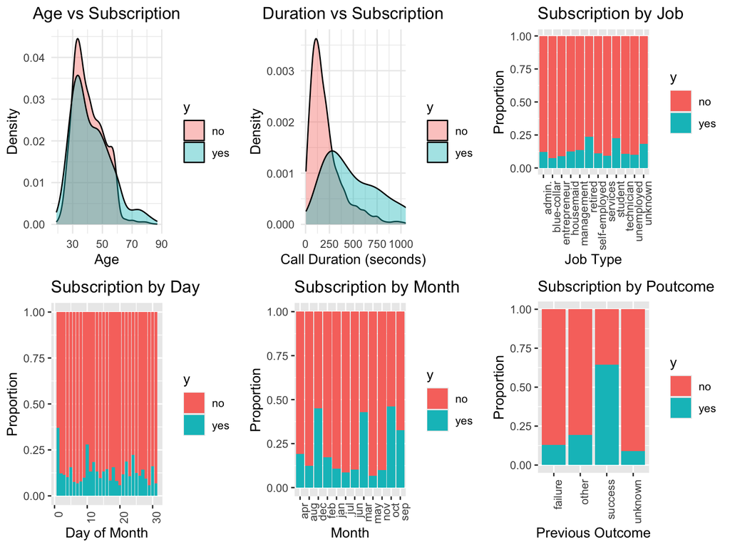

# Feature Engineering

- **Encoded target:**
  - y = 1 for “yes” and y = 0 for “no”.
- **Converted character variables to factors:**
  - job, marital, default, housing, loan, contact, month, poutcome.
- **Addressed skewed balance:**
  - Performed Box–Cox analysis on shifted balance (balance + 3314).
  - Optimal λ near 0 → used log transformation of shifted balance.
- **Created:**
  - balance_log as the transformed response for linear regression.

# Linear Regression – Purpose

- **Question:**
  - Do marital status and education help explain a client’s average yearly balance?
- **Response:**
  - balance (and later balance_log).
- **Predictors:**
  - marital (married, single, divorced/widowed)
  - education (primary, secondary, tertiary, unknown)
- **Performed:**
  - Backwards step-wise model selection
  - 5-fold cross-validation comparing models with and without interaction.

# Regression table

Reduced Model: Regression Coefficients

|  | Estimate | Std. Error | t value | Pr(>&#124;t&#124;) |
| --- | --- | --- | --- | --- |
| (Intercept) | 8.3235230 | 0.0222541 | 374.021844 | 0.0000000 |
| maritalmarried | 0.0441041 | 0.0187416 | 2.353277 | 0.0186514 |
| maritalsingle | 0.0436551 | 0.0206966 | 2.109290 | 0.0349745 |
| educationsecondary | -0.0251414 | 0.0173792 | -1.446637 | 0.1480679 |
| educationtertiary | 0.0522989 | 0.0188702 | 2.771502 | 0.0056027 |
| educationunknown | 0.0579406 | 0.0326615 | 1.773974 | 0.0761348 |

# Regression Results

- **Reference categories:**
  - **Marital:** divorced/widowed
  - **Education:** primary
- **Findings:**
  - **Married clients:** higher balances than divorced/widowed.
    - Married individuals have 4.4% higher log-balance than divorced individuals on average, controlling for education.
  - **Single clients:** slightly higher balances (borderline significant).
    - Single individuals have an log-balance 4.37% higher than divorced individuals.
  - **Tertiary education:** significantly higher balances than primary.
    - Tertiary education is associated with roughly 5% higher log-balance than primary.
  - Secondary and unknown education: not significantly different.
- **Model fit:**
  - R² ≈ 0.009 → small portion of balance variation explained.
  - MSE large, indicating substantial unexplained variability.

# Logistic Regression – Purpose

- **Goals:**
  - Identify important predictors of subscription.
  - Build a reduced model that is simpler but still predictive.
- **Response:**
  - y (1 = subscribed, 0 = not subscribed).
- **Full model included:**
  - **Demographics:** age, job, marital, education
  - **Financial:** default, balance, housing, loan
  - **Campaign:** contact, day, month, duration, campaign, pdays, previous, poutcome
- **Model selection**
  - Backward stepwise selection using AIC.
  - Started from the full model and removed weak predictors.
  - Final model balances **good fit** with **interpretability**.

# Logistic Regression Table

Reduced Logistic Regression Model: Coefficients

|  | Estimate | Std. Error | z value | Pr(>&#124;z&#124;) |
| --- | --- | --- | --- | --- |
| (Intercept) | -2.7318547 | 0.3608341 | -7.5709438 | 0.0000000 |
| maritalmarried | -0.5108288 | 0.1709685 | -2.9878530 | 0.0028094 |
| maritalsingle | -0.3181354 | 0.1864058 | -1.7066816 | 0.0878813 |
| educationsecondary | 0.1268075 | 0.1827658 | 0.6938248 | 0.4877921 |
| educationtertiary | 0.3810998 | 0.1913291 | 1.9918549 | 0.0463870 |
| educationunknown | -0.2831229 | 0.3395018 | -0.8339365 | 0.4043168 |
| housingyes | -0.3434167 | 0.1329758 | -2.5825498 | 0.0098073 |
| loanyes | -0.6430899 | 0.1981746 | -3.2450674 | 0.0011742 |
| contacttelephone | -0.0077099 | 0.2217915 | -0.0347617 | 0.9722698 |
| contactunknown | -1.4577768 | 0.2253170 | -6.4698925 | 0.0000000 |
| day | 0.0162954 | 0.0081149 | 2.0080895 | 0.0446338 |
| monthaug | -0.3180448 | 0.2457796 | -1.2940242 | 0.1956571 |
| monthdec | 0.2027593 | 0.6661682 | 0.3043665 | 0.7608487 |
| monthfeb | 0.1398131 | 0.2917392 | 0.4792400 | 0.6317679 |
| monthjan | -1.0851644 | 0.3768278 | -2.8797358 | 0.0039801 |
| monthjul | -0.7312482 | 0.2473493 | -2.9563387 | 0.0031132 |
| monthjun | 0.5600454 | 0.2975296 | 1.8823180 | 0.0597929 |
| monthmar | 1.6262687 | 0.3813054 | 4.2650025 | 0.0000200 |
| monthmay | -0.4734989 | 0.2311010 | -2.0488832 | 0.0404735 |
| monthnov | -0.8618761 | 0.2700920 | -3.1910465 | 0.0014176 |
| monthoct | 1.4102741 | 0.3255826 | 4.3315398 | 0.0000148 |
| monthsep | 0.7558952 | 0.4089156 | 1.8485359 | 0.0645249 |
| duration | 0.0041838 | 0.0001992 | 21.0055249 | 0.0000000 |
| campaign | -0.0722161 | 0.0281375 | -2.5665456 | 0.0102717 |
| poutcomeother | 0.4813847 | 0.2659176 | 1.8102781 | 0.0702527 |
| poutcomesuccess | 2.4145453 | 0.2681035 | 9.0060191 | 0.0000000 |
| poutcomeunknown | -0.0931105 | 0.1847998 | -0.5038451 | 0.6143702 |

# Logistic Regression – Reduced Model

# Model Performance

- Goal: evaluate how well our models predict **client balance** (linear regression) and **subscription** (logistic regression).
- Use:
  - **5-fold cross-validation** and MSE for the linear regression models.
  - **ROC curves and AUC** for the logistic regression models.
- This tells us whether the models are reliable enough to guide marketing decisions and which specification performs best.

# Linear Regression: 5-Fold Cross-Validation

- Two models for balance:
  - **M1:** marital + education (main effects only)
  - **M2:** marital * education (adds interaction)
- Average MSEs are very similar and the curves across folds nearly overlap.
- Interpretation → Adding the interaction yields **no meaningful improvement**, so the simpler main-effects model is preferred for prediction.

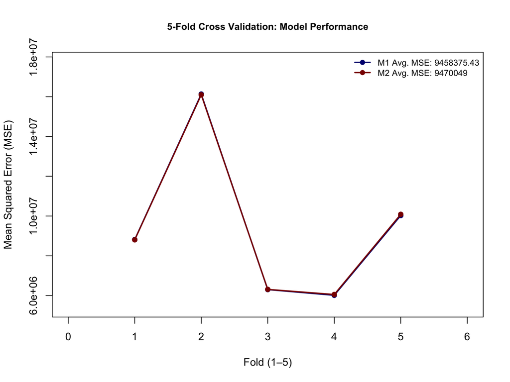

# Logistic Regression: Full Model Performance

- **Test AUC = 0.8757** → model correctly ranks a random subscriber above a random non-subscriber about **87.6%** of the time (strong discrimination).
- Optimal cutoff probability ≈ **0.094**:
  - Probabilities ≥ 0.094 → predict “subscribe”.

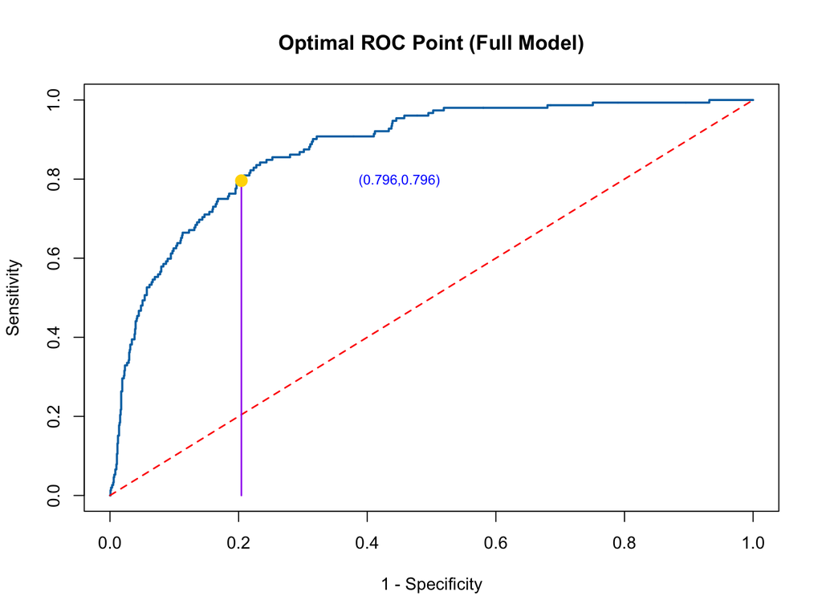

# Logistic Regression: Cross-Validation & Model Choice

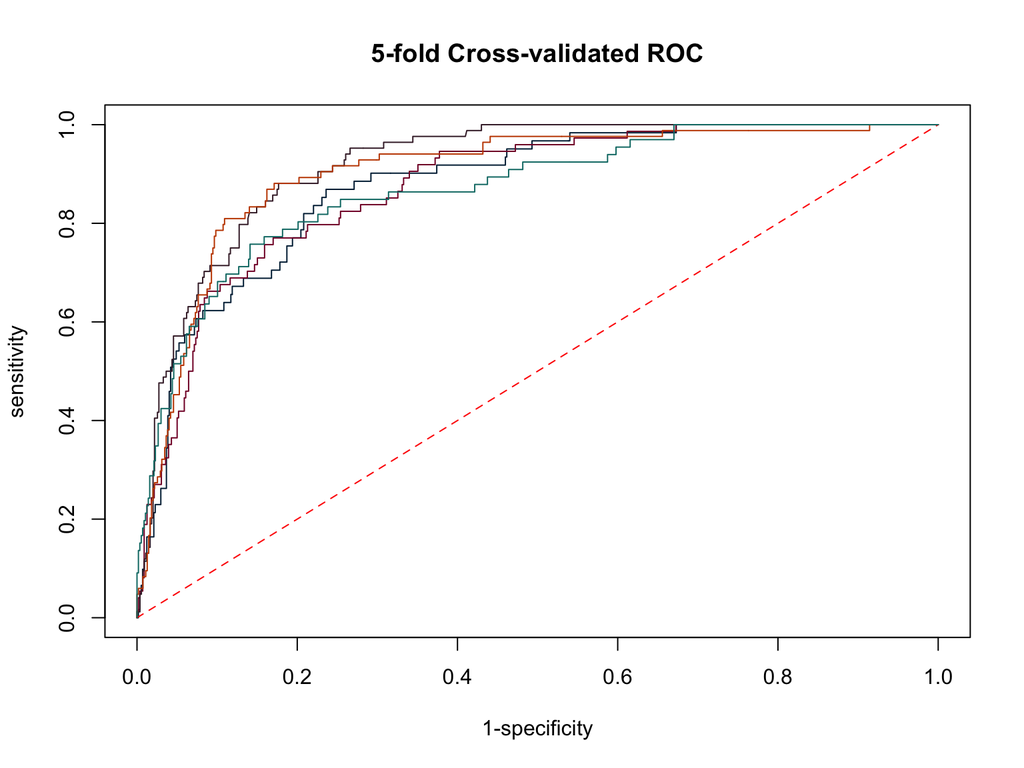

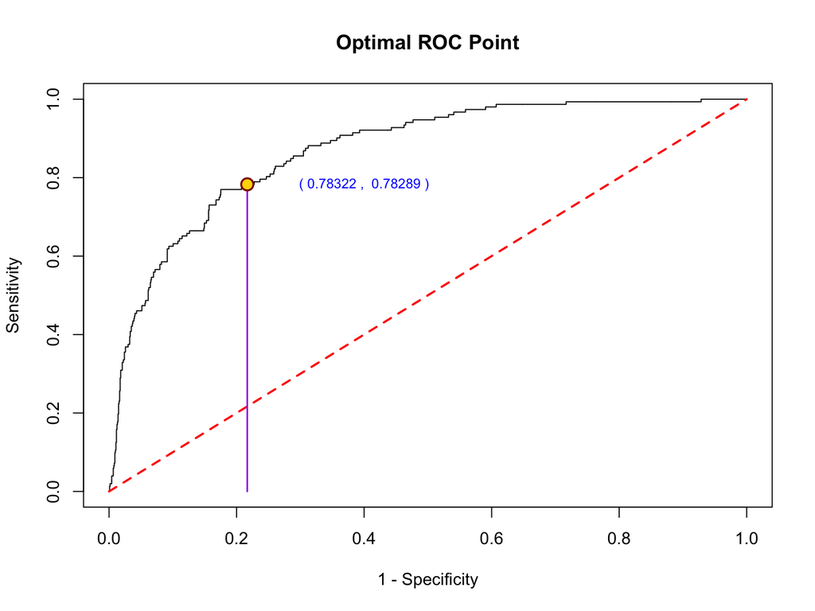

# Predicitive Model

- Two hypothetical clients were evaluated using the final logistic model:
  - **Client 1:** -Single, tertiary education, good balance, no loans, cellular contact, March, longer duration, success in previous campaign.
    - Predicted to subscribe (y = 1).
  - **Client 2:** -Married, secondary education, lower balance, housing and personal loans, unknown contact, October, shorter call, prior failure. -Predicted to not subscribe (y = 0).
- Shows how model can support targeted marketing.

Predicted Probability and Response (cut-off = 0.091)

| Marital Status | Education Level | Balance (€) | Housing Loan | Personal Loan | Contact Method | Day | Month | Call Duration (sec) | Campaign Contacts | Previous Outcome | Predicted Probability | Predicted Response |
| --- | --- | --- | --- | --- | --- | --- | --- | --- | --- | --- | --- | --- |
| single | tertiary | 1200 | no | no | cellular | 15 | mar | 250 | 1 | success | 0.930 | 1 |
| married | secondary | 300 | yes | yes | unknown | 23 | oct | 120 | 4 | failure | 0.028 | 0 |

# Recommendations

- **Focus marketing efforts on:**
  - Clients with tertiary education.
  - Clients with prior successful campaigns.
  - Months with historically higher success (March, October, September).
- **Operational strategies:**
  - Allow sufficient call duration to engage clients.
  - Avoid excessive contacts (high campaign values reduce odds).
  - Improve data collection to reduce “unknown” contact and poutcome categories.

# Limitations

- **Linear regression:**
  - Balance remains skewed even after transformation; conclusions should be interpreted cautiously.
  - R² is low; many other factors likely influence balance.
- **Logistic regression:**
  - Duration is an outcome of the call, not a pre-campaign feature.
    - It happens during the call, so it can’t be used for true pre-call targeting.
  - Data from a single bank and time period; limited generalizability.
    - Findings may not apply to other banks, regions, or time periods.

# Overall Conclusions

- **Linear regression:**
  - Marital status and education are statistically related to balance, but explain only a small fraction of variability.
- **Logistic regression:**
  - Final reduced model achieves strong predictive performance (AUC ≈ 0.87).
  - Key drivers of term deposit subscription:
    - Call duration
    - Previous campaign success
    - Certain months
    - Loan and housing status
    - Marital status and contact method
- The final logistic model offers a useful, interpretable tool for targeting future marketing campaigns.